# Технологический практикум (практикум на ЭВМ)

### Рукавица Артём Кириллович, 316

## 0. Описание датасета. Подготовка рабочего окружения

В качестве датасета для выполнения задания я выбрал данные о показателях сна и здоровья. Этот датасет состоит из нескольких столбцов:

1. Heart Rate Variability: Изменения интервалов между ударами сердца.
2. Body Temperature: Температура тела в градусах Цельсия.
3. Movement During Sleep: Количество движений во время сна.
4. Sleep Duration Hours: Длительность сна.
5. Sleep Quality Score: Качество сна.
6. Caffeine Intake (mg): Количество потребления кофеина в миллиграммах.
7. Stress Level: Уровень стресса.
8. Bedtime Consistency: Регулярность режима сна. Принимает значения из отрезка [0; 1], где более низкие значения указывают на большую нерегулярность.
9. Light Exposure Hours: Часы воздействия света в течение дня. Отражает типичное дневное освещение.

Мы готовы начинать! Покдлючим библиотеки, а также датасет к рабочему окружению.

```python
import pandas as pd
import numpy as np
from scipy import stats
import seaborn as sns
import statsmodels.api as sm
import matplotlib.pyplot as plt
from scipy.stats import shapiro, spearmanr, kendalltau
```

```python
sleep = pd.read_csv("D:\\Artyom\\ВМК\\5 семестр\\Практикум\\SleepHealth.csv")
sleep.head(3)
```

|  | HeartRateVariability | BodyTemperature | MovementDuringSleep | SleepDurationHours | SleepQualityScore | CaffeineIntakeMg | StressLevel | BedtimeConsistency | LightExposureHours |
| --- | --- | --- | --- | --- | --- | --- | --- | --- | --- |
| 0 | 79.934283 | 37.199678 | 1.324822 | 4.638289 | 1.0 | 107.624032 | 2.771837 | 0.657037 | 7.933949 |
| 1 | 67.234714 | 36.962317 | 1.855481 | 6.209422 | 1.0 | 104.658589 | 3.738138 | 0.144464 | 6.992699 |
| 2 | 82.953771 | 36.529815 | 1.207580 | 6.879592 | 10.0 | 0.000000 | 3.115880 | 0.642949 | 7.655250 |

## 1. Описание, краткие характеристики (максимумы-минимумы, средние значения, пропуски и т.п.)

```python
sleep.describe()
```

|  | HeartRateVariability | BodyTemperature | MovementDuringSleep | SleepDurationHours | SleepQualityScore | CaffeineIntakeMg | StressLevel | BedtimeConsistency | LightExposureHours |
| --- | --- | --- | --- | --- | --- | --- | --- | --- | --- |
| count | 1000.000000 | 1000.000000 | 1000.000000 | 1000.000000 | 1000.000000 | 1000.000000 | 1000.000000 | 1000.000000 | 1000.000000 |
| mean | 70.386641 | 36.535418 | 2.005834 | 7.471921 | 2.592946 | 148.260148 | 4.940956 | 0.504222 | 8.036684 |
| std | 19.584319 | 0.498727 | 0.983454 | 1.540699 | 2.979500 | 94.031760 | 2.032708 | 0.204137 | 2.023371 |
| min | 5.174653 | 35.029806 | -1.019512 | 3.105827 | 1.000000 | 0.000000 | 0.000000 | 0.000000 | 0.326689 |
| 25% | 57.048194 | 36.196879 | 1.352000 | 6.393869 | 1.000000 | 80.630719 | 3.489725 | 0.361569 | 6.726291 |
| 50% | 70.506012 | 36.531539 | 1.999749 | 7.500277 | 1.000000 | 145.717293 | 4.890507 | 0.500996 | 8.038248 |
| 75% | 82.958878 | 36.864441 | 2.660915 | 8.500418 | 2.537789 | 211.244685 | 6.399490 | 0.644680 | 9.354408 |
| max | 147.054630 | 38.096554 | 5.926238 | 12.364639 | 10.000000 | 400.000000 | 10.000000 | 1.000000 | 14.754766 |

```python
sleep.isna().sum()
```

```
HeartRateVariability    0
BodyTemperature         0
MovementDuringSleep     0
SleepDurationHours      0
SleepQualityScore       0
CaffeineIntakeMg        0
StressLevel             0
BedtimeConsistency      0
LightExposureHours      0
dtype: int64
```

Обратим внимание на то, что пропусков в данных нет.

## 2. Реализовать аппроксимацию распределений данных с помощью ядерных оценок.

**Ядерная оценка плотности** (Kernel Density Estimation, KDE) — это метод оценки вероятностной плотности случайной величины. Этот метод позволяет аппроксимировать неизвестную функцию плотности распределения по выборке данных. Визуально KDE позволяет сгладить данные и создать непрерывную кривую, которая описывает, как распределены наблюдения.

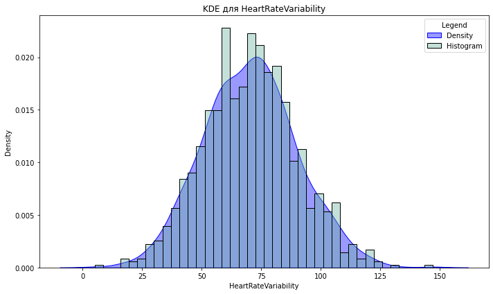

```python
plt.figure(figsize=(10, 6))
sns.kdeplot(sleep['HeartRateVariability'],
            fill=True,
            alpha=0.4,
            linewidth=1,
            color='blue',
            label='Density')
sns.histplot(sleep['HeartRateVariability'],
             bins=40,
             stat='density',
             color='#69b3a2',
             alpha=0.4,
             edgecolor='black',
             label='Histogram')
plt.legend(title='Legend', loc='upper right')
plt.title('KDE для HeartRateVariability')
plt.tight_layout()
plt.show()
```

1. Распределение для HeartRateVariability имеет симметричную колоколообразную фор му, схожую с нормальным распределением. Центр сосредоточен около среднего зна чения (порядка 70).
2. Выраженные выбросы отсутствуют.
3. Плотность, отображаемая KDE, согласуется с гистограммой, что подтверждает кор ректность метода сглаживания

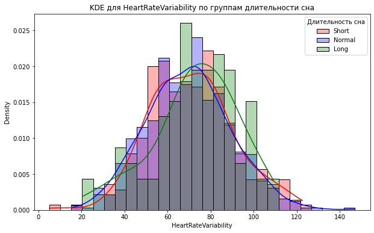

```python
sleep['SleepDurationHoursCorrected'] = round(sleep['SleepDurationHours'])
sleep['SleepDurationHoursGroups'] = pd.cut(sleep['SleepDurationHoursCorrected'],
                                           bins=[2, 6, 9, 12],
                                           labels=['Short', 'Normal', 'Long'],
                                           right=True)

plt.figure(figsize=(10, 6))
edges = np.histogram_bin_edges(sleep['HeartRateVariability'], bins='fd')
sns.histplot(data=sleep[sleep.SleepDurationHoursGroups == 'Short'].HeartRateVariability, stat='density', kde=True,
             bins=edges,
             color='red', alpha=0.3,
             label='Short')

sns.histplot(data=sleep[sleep.SleepDurationHoursGroups == 'Normal'].HeartRateVariability, stat='density', kde=True,
             bins=edges,
             color='blue', alpha=0.3,
             label='Normal')

sns.histplot(data=sleep[sleep.SleepDurationHoursGroups == 'Long'].HeartRateVariability, stat='density', kde=True,
             bins=edges,
             color='green', alpha=0.3,
             label='Long')


plt.xlabel('HeartRateVariability')
plt.title('KDE для HeartRateVariability по группам длительности сна')
plt.legend(title='Длительность сна')
plt.show()
```

## 3. Реализовать анализ данных с помощью cdplot, dotchart, boxplot и stripchart.

#### cdplot

**cdplot** (Conditional Density Plot) — это график условной плотности, который показывает распределение одной непрерывной переменной в зависимости от другой категориальной переменной. График помогает визуализировать, как распределение непрерывной переменной изменяется в зависимости от различных категорий.

Для простоты анализа данных округлим значения длительности сна до целого числа.

```python
sleep['SleepDurationHoursCorrected'] = round(sleep['SleepDurationHours'])
np.unique(sleep['SleepDurationHoursCorrected'])
```

```
array([ 3.,  4.,  5.,  6.,  7.,  8.,  9., 10., 11., 12.])
```

Мы получили 10 натуральных значений от 3 до 12.

Построим график зависимости сна от принятого кофеина.

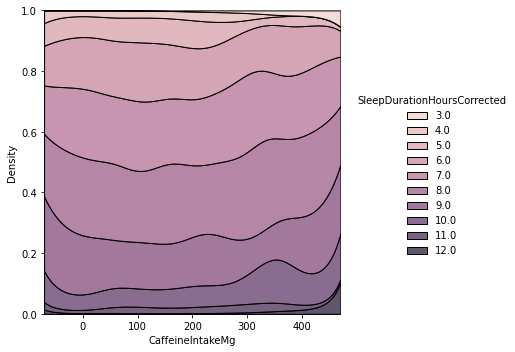

```python
sns.displot(data = sleep, hue = "SleepDurationHoursCorrected", multiple = "fill", x = "CaffeineIntakeMg", kind = "kde");
```

На этом графике трудно разобраться, что к чему относится. Разделим для простоты длительность сна на три категории: короткий сон (3-6 часов), сон средней продолжительности (7-9 часов) и долгий сон (10-12 часов).

```python
sleep['SleepDurationHoursGroups'] = pd.cut(sleep['SleepDurationHoursCorrected'],
                                           bins=[2, 6, 9, 12],
                                           labels=['Short', 'Normal', 'Long'],
                                           right=True)
```

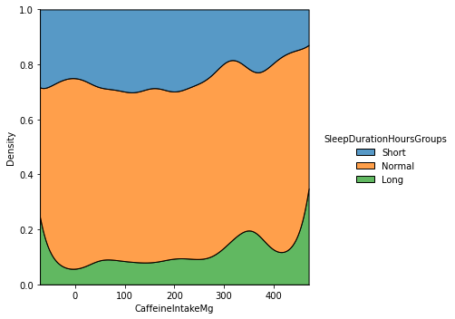

```python
sns.displot(data = sleep, hue = "SleepDurationHoursGroups", multiple = "fill", x = "CaffeineIntakeMg", kind = "kde");
```

#### dotchart

**Dotchart** (точечная диаграмма) — это вид графика, который отображает значения данных с помощью точек. Точечные диаграммы используются для визуализации числовых данных и сравнений между несколькими категориями. Этот тип графика похож на столбчатую диаграмму, но вместо столбцов используются точки для отображения значений.

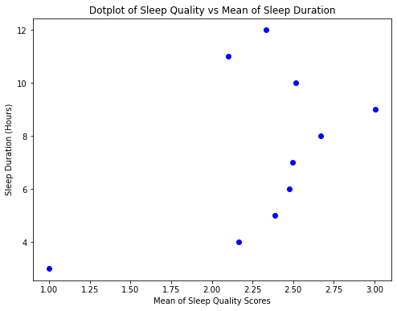

```python
sleep['SleepQualityScore'] = sleep['SleepQualityScore'].round()
result = sleep.groupby('SleepDurationHoursCorrected')['SleepQualityScore'].mean().reset_index()
plt.figure(figsize=(8, 6))
plt.scatter(result['SleepQualityScore'], result['SleepDurationHoursCorrected'], color='blue')

plt.title("Dotplot of Sleep Quality vs Mean of Sleep Duration")
plt.xlabel("Mean of Sleep Quality Scores")
plt.ylabel("Sleep Duration (Hours)")

plt.show()
```

- Данный график подтверждает гипотезу о том, что качество сна тесно связано с его продолжительностью: чем больше человек спит, тем лучше его сон оценивается в среднем. Однако после определенного порога (~8-9 часов) дальнейшее увеличение продолжительности сна уже не приводит к столь значимому улучшению качества сна (а, наоборот, даже ухудшает его: по словам экспертов, после чрезмерно долгого сна человек может испытывать мигрень, позвоночную и мышечную боль и прочие симптомы, поэтому ощущения после подобного сна ухудшаются).

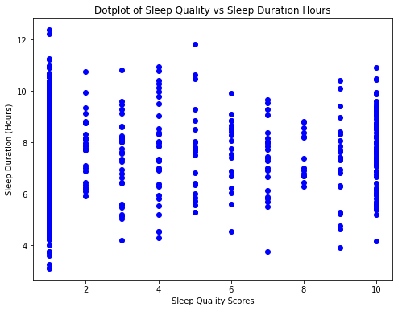

```python
plt.figure(figsize=(8, 6))
plt.scatter(sleep['SleepQualityScore'], sleep['SleepDurationHours'], color='blue')

plt.title("Dotplot of Sleep Quality vs Sleep Duration Hours")
plt.xlabel("Sleep Quality Scores")
plt.ylabel("Sleep Duration (Hours)")
plt.show()
```

#### boxplot

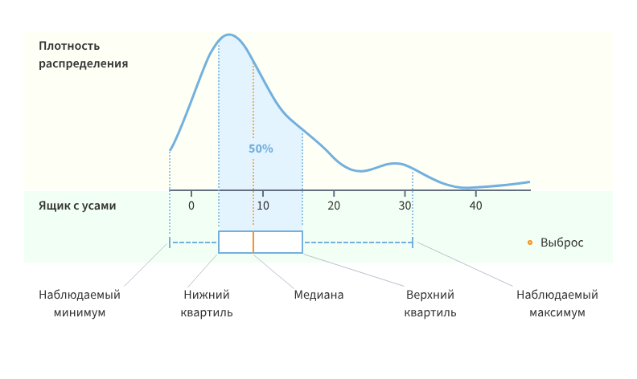

**Boxplot** ("ящик с усами") — это графический метод визуализации числовых данных, который отображает пять основных статистических показателей: минимальное значение, первый квартиль (Q1), медиану (Q2), третий квартиль (Q3), и максимальное значение. Это мощный инструмент для выявления распределения данных, межквартильного размаха и наличия выбросов.

Основные элементы boxplot:

- Медиана (Q2) -- это линия внутри прямоугольника, представляющая 50-й перцентиль данных, то есть середину распределения. Это центральное значение, которое делит данные пополам.
- Первый квартиль (Q1) -- это нижняя граница ящика, представляющая 25-й перцентиль.
- Третий квартиль (Q3) -- верхняя граница ящика, представляющая 75-й перцентиль.
- Межквартильный размах (IQR) -- это расстояние между первым и третьим квартилями: IQR = Q3 - Q1. Этот размах используется для определения разброса данных и определения выбросов.
- Усы (Whiskers) -- линии, которые простираются от краев ящика (Q1 и Q3) до крайних точек данных, которые находятся в пределах 1.5 IQR от Q1 и Q3. Усы помогают определить диапазон, в который попадает основная часть данных. Любые точки за пределами этого диапазона считаются выбросами.
- Выбросы (Outliers) -- это точки, которые находятся за пределами 1.5 IQR от Q1 и Q3, отображаются как отдельные точки за пределами усов. Эти данные могут быть аномальными или ошибочными значениями, но также могут быть важными для анализа.

Для серии boxplot-ов для удобства разделим уровень стресса на четыре категории: низкий, средний, высокий, очень высокий.

```python
sleep['StressLevelGroup'] = pd.cut(sleep['StressLevel'],
                                   bins=[-1, 3, 6, 8, 10],
                                   labels=['Low', 'Medium', 'High', 'Very High'],
                                   right=True)
```

Исследуем длительность сна от уровня стресса.

```python
def boxplot(x, y):
    plt.figure(figsize=(8, 6))
    sns.boxplot(data=sleep,
                x=x,
                y=y,
                color="slateblue",
                showfliers=True,
                boxprops={'alpha':0.2})
    plt.xlabel("Stress Level by Groups")
    plt.ylabel(y)
    plt.title(f"Boxplot of {y} by Stress Level Groups")
    plt.show()
```

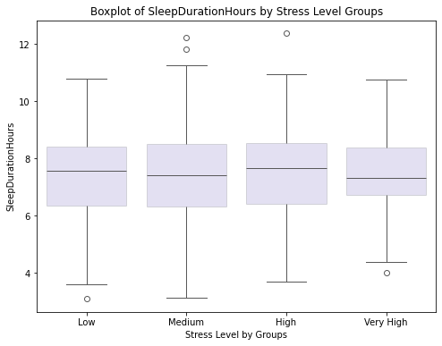

```python
boxplot(x='StressLevelGroup', y='SleepDurationHours')
```

Длительность сна слабо зависит от уровня стресса, однако мы можем обратить внимание на выбросы в группе Medium (вполне возможно, что два человека спят дольше по другим причинам, не из-за среднего уровня стресса).

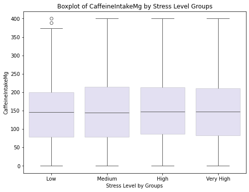

```python
boxplot(x='StressLevelGroup', y='CaffeineIntakeMg')
```

Потребление кофеина не сильно влияет на уровень стресса.

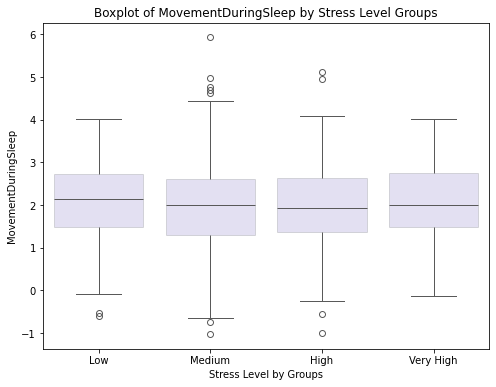

```python
boxplot(x='StressLevelGroup', y='MovementDuringSleep')
```

- Медиана (центральная линия внутри каждого ящика) почти одинакова для всех групп стресса и находится на уровне около 2 единиц движения. Это указывает на то, что средний уровень движения во время сна не сильно изменяется в зависимости от уровня стресса.
- В группах Medium, High выбросы особенно видны выше уровня 4 единиц движения, что может свидетельствовать о том, что у некоторых людей с высоким уровнем стресса наблюдается аномально большое количество движения во время сна, однако выбросов в группах Low и Very High почти что нет.

#### stripchart

**Stripchart** — это график, который отображает распределение данных, представляя каждое отдельное наблюдение в виде точки на оси. Он полезен для визуализации небольших наборов данных и позволяет увидеть каждое уникальное значение в одном ряду.

Основные характеристики stripchart:

- Каждая точка — это одно наблюдение: В отличие от boxplot, который отображает статистическое обобщение данных, stripchart отображает каждое наблюдение на графике.
- Сравнение категорий: Stripchart может отображать данные для нескольких категорий рядом, что позволяет легко увидеть различия между ними.
- Перекрытие точек: Когда несколько значений оказываются близко друг к другу, точки могут перекрываться, поэтому иногда используют небольшой "джиттер" (искусственное смещение) по оси, чтобы разделить их визуально.

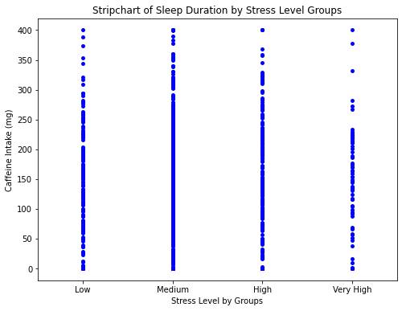

```python
plt.figure(figsize=(8, 6))
sns.stripplot(data=sleep, x='StressLevelGroup', y='CaffeineIntakeMg', jitter=False, color='blue')
plt.xlabel('Stress Level by Groups')
plt.ylabel('Caffeine Intake (mg)')
plt.title('Stripchart of Sleep Duration by Stress Level Groups')
plt.show()
```

График трудно анализировать, построим такой же, но со смещением внутри групп.

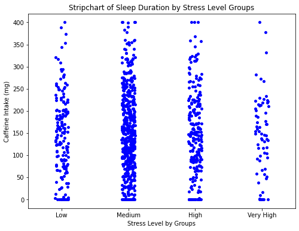

```python
plt.figure(figsize=(8, 6))
sns.stripplot(data=sleep, x='StressLevelGroup', y='CaffeineIntakeMg', jitter=True, color='blue')
plt.xlabel('Stress Level by Groups')
plt.ylabel('Caffeine Intake (mg)')
plt.title('Stripchart of Sleep Duration by Stress Level Groups')
plt.show()
```

## 4. Проверить, являются ли наблюдения выбросами с точки зрения формальных статистических критериев Граббса и Q-теста Диксона.

Для этих критериев требуется нормальность выборки, проверим часть столбцов на нормальность, например, при помощи критерия Шапиро — Уилка. Код на R показал, что значения столбца MovementDuringSleep распределены нормально. Убедимся в этом и на Python. Выведем p-значения этого критерия.

```python
stats.shapiro(sleep['MovementDuringSleep']).pvalue
```

```
0.717817251078054
```

`p-value > 0.05`, поэтому эти значения действительно распределены нормально, применимы критерий Граббса и Q-тест Диксона. Построим гистограмму для визуального сравнения с нормальным распределением.

```
array([[<Axes: title={'center': 'MovementDuringSleep'}>]], dtype=object)
```

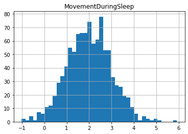

```python
sleep.hist(column='MovementDuringSleep', bins=40)
```

Действительно, и внешне распределение похоже на нормальное. Применим критерий Граббса и Q-тест Диксона.

#### Критерий Граббса

Критерий Граббса формулируется следующим образом: Статистика `G` для максимума вычисляется следующим образом: $$ G = \frac{X_{max} - \bar X}{s}, $$ где `X_max` -- максимальное значение, которое мы проверяем на принадлежность выбросам, X¯ -- среднее выборки, `s` -- стандартное отклонение выборки. Если G достигает критического значения из таблицы Граббса для конкретного уровня значимости, то `X_max` - это действительно выброс.

Аналогично формулируется критерий Граббса для минимума.

Найдем выбросы в выборке MovementDuringSleep, предварительно округлив значения в этом столбце до двух знаков после запятой.

```python
sleep['MovementDuringSleep'] = round(sleep['MovementDuringSleep'], 2)
```

```python
from outliers import smirnov_grubbs as grubbs

subdata = sleep['MovementDuringSleep'].tolist()
outlier_idx = grubbs.max_test_indices(subdata, alpha=.05)[0]
outlier_idx
```

```
895
```

Проверим, какая строчка соответствует данному выбросу.

```python
sleep.iloc[[outlier_idx]]
```

|  | HeartRateVariability | BodyTemperature | MovementDuringSleep | SleepDurationHours | SleepQualityScore | CaffeineIntakeMg | StressLevel | BedtimeConsistency | LightExposureHours | SleepDurationHoursCorrected | SleepDurationHoursGroups | StressLevelGroup |
| --- | --- | --- | --- | --- | --- | --- | --- | --- | --- | --- | --- | --- |
| 895 | 82.974198 | 36.314994 | 5.93 | 9.002448 | 1.0 | 250.673007 | 3.922419 | 0.390168 | 12.091309 | 9.0 | Normal | Medium |

Убедимся на boxplot, действительно ли значение, соответствующее этому индексу, -- выброс

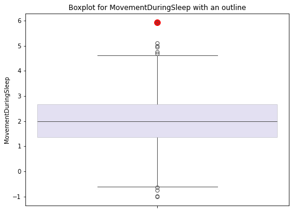

```python
plt.figure(figsize=(8, 6))
sns.boxplot(y='MovementDuringSleep', data=sleep, color='slateblue', boxprops=dict(alpha=0.2))
plt.scatter(x=0, y=5.93, color='red', s=100)
plt.title("Boxplot for MovementDuringSleep with an outline")
```

#### Q-тест Диксона

Для теста Диксона существуют ограничение: он может корректно анализировать только малые выборки данных (от 3 до 20). По критерию Граббса мы знаем, что выброс находится на 895 позиции датасета, поэтому ограничим поиск выброса на позициях от 890 до 909.

Для проведения q-теста Диксона необходимо отсоритровать массив значений по возрастанию и посчитать число Q по формуле:

$$ Q = \frac{| potential \ outlier - nearest \ neighbor | }{maximum \ value - minimum \ value} $$

Далее необходимо сравнить полученное `Q` с критическим значением из таблицы `Q_table`, соответствующее количеству значений в выборке на определенном уровне значимости. Если `Q > Q_table`, то `potential outlier` действительно является выбросом.

Критические значения взяты из документа: https://guiok.github.io/download/dixon_q_test.pdf

```python
def dixon_q_test(data, side='right'):
    # 90% confidence level values
    dixon_critical_values = {
        3: 0.941, 4: 0.765, 5: 0.642, 6: 0.560, 7: 0.507, 8: 0.468, 9: 0.437, 10: 0.412, 11: 0.392,
        12: 0.376, 13: 0.361, 14: 0.349, 15: 0.338, 16: 0.329, 17: 0.320, 18: 0.313, 19: 0.306, 20: 0.300
    }
    data = np.sort(data)
    n = len(data)
    if n < 3 or n > 20:
        raise ValueError("Q-тест Диксона может быть корректно проведен на малых выборках размером между 3 и 20.")
    R = data[-1] - data[0]
    if side == 'right':
        Q = (data[-1] - data[-2]) / R
        outlier = data[-1]
    elif side == 'left':
        Q = (data[1] - data[0]) / R
        outlier = data[0]
    else:
        raise ValueError("Может быть только два значения: left или right.")
    Q_crit = dixon_critical_values.get(n)
    is_outlier = Q > Q_crit
    return Q, outlier, is_outlier

subdata = sleep.loc[890:909, sleep.columns == 'MovementDuringSleep'].reset_index(drop=True).sort_values(by=['MovementDuringSleep'])
Q_value, suspected_outlier, is_outlier = dixon_q_test(subdata, side='right')
print(f"Q-value: {Q_value[0]:0.2f}, Suspected outlier: {suspected_outlier[0]:0.2f}, Is outlier: {is_outlier[0]}")
```

```
Q-value: 0.36, Suspected outlier: 5.93, Is outlier: True
```

## 5. Воспользоваться инструментами для заполнения пропусков в данных. Пропуски внести вручную и сравнить результаты заполнения с истинными значениями.

Вспомним, что в данных нет пропусков:

```python
sleep.isna().sum()
```

```
HeartRateVariability           0
BodyTemperature                0
MovementDuringSleep            0
SleepDurationHours             0
SleepQualityScore              0
CaffeineIntakeMg               0
StressLevel                    0
BedtimeConsistency             0
LightExposureHours             0
SleepDurationHoursCorrected    0
SleepDurationHoursGroups       0
StressLevelGroup               0
dtype: int64
```

Это не проблема: попробуем внести пропуски, например, в столбец BodyTemperature. Создаим массив из случайных 10 чисел. Значения, соответствующие данным индексам, обратим в NA.

```python
indices = [894, 2, 198, 753, 186, 78, 45, 187, 952, 886]
print(sleep['BodyTemperature'][indices])
```

```
894    36.455819
2      36.529815
198    36.611957
753    35.584684
186    36.008756
78     37.250380
45     36.941830
187    36.387683
952    36.047134
886    36.095198
Name: BodyTemperature, dtype: float64
```

```python
print('median: ', sleep['BodyTemperature'].median())
print('mean:   ', sleep['BodyTemperature'].mean())
```

```
median:  36.53153856616453
mean:    36.53541811862458
```

```python
sleep.loc[indices, 'BodyTemperature'] = np.nan
```

Проверим, удалились ли эти значения?

```python
sum(sleep['BodyTemperature'].isna())
```

```
10
```

Все отлично! Теперь построим гистограмму для измененных данных.

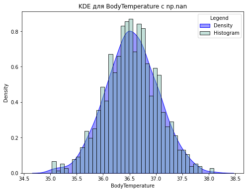

```python
def kde_temperature(replace):
    plt.figure(figsize=(8, 6))
    sns.kdeplot(sleep['BodyTemperature'], label='Density', color='blue', linewidth=1, alpha=0.4, fill=True)
    sns.histplot(sleep['BodyTemperature'], bins=40, stat='density', color='#69b3a2', alpha=0.4, edgecolor='black')
    plt.legend(['Density', 'Histogram'], loc='upper right', title="Legend", fontsize=10)
    plt.title(f"KDE для BodyTemperature {replace}")
    plt.show()

kde_temperature('с np.nan')
```

Заполним пропущенные значения медианой.

```python
med = sleep['BodyTemperature'].median()
sleep.loc[indices, 'BodyTemperature'] = med
print(med)
```

```
36.533711556938066
```

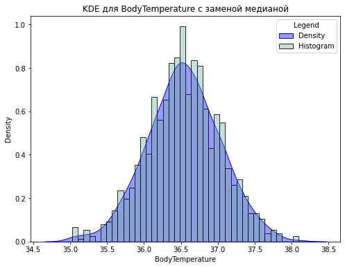

```python
kde_temperature('c заменой медианой')
```

Заполним пропущенные значения средним.

```python
mean = sleep['BodyTemperature'].mean()
sleep.loc[indices, 'BodyTemperature'] = mean
print(mean)
```

```
36.53684197818809
```

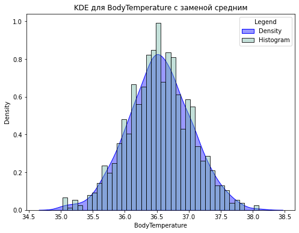

```python
kde_temperature('c заменой средним')
```

- Можно сделать вывод о том, что методы заполнения пропусков медианными и средними значениями в целом дают довольно близкие результаты.

## 6. Анализ нормального распределения (на малых и больших выборках).

Сгенерируем выборки из нормального распределения разных объемов с разными средними и дисперсиями.

```python
data1 = np.random.normal(loc=0, scale=1, size=50)
data2 = np.random.normal(loc=2, scale=2, size=100)
data3 = np.random.normal(loc=1, scale=4, size=5000)
data4 = np.random.normal(loc=11, scale=3, size=2000)
data5 = np.random.normal(loc=1, scale=1, size=1000)
```

#### Анализ с помощью графиков эмпирических функций распределений

```python
from scipy.stats import norm
def my_cdf(data, color, text):
    sns.displot(data = data, kind = "ecdf", color = color, label='Эмпирическая ФР').set(title='Эмпирическая ФР ' + text)
    x = np.linspace(min(data), max(data), 1000)
    y = norm.cdf(x, loc=np.mean(data), scale=np.std(data))
    plt.plot(x, y, color='black', linestyle='--', label='Нормальная ФР')
    plt.legend()
```

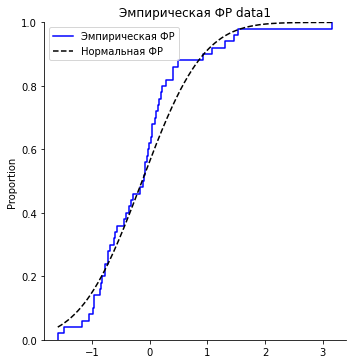

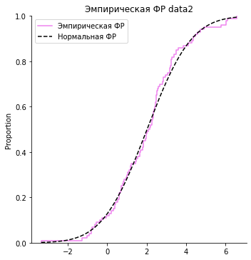

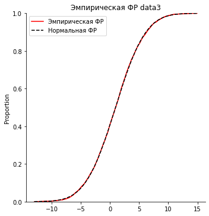

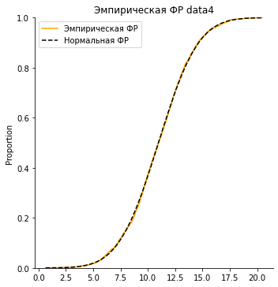

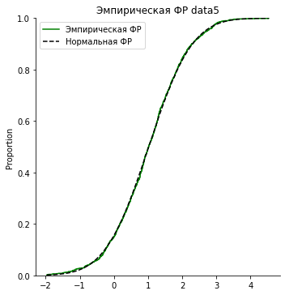

```python
my_cdf(data1, 'blue', 'data1')
my_cdf(data2, 'violet', 'data2')
my_cdf(data3, 'red', 'data3')
my_cdf(data4, 'orange', 'data4')
my_cdf(data5, 'green', 'data5')
```

#### Анализ с помощью графиков квантилей

```python
def qqgraph(data, data_name="", point_color="blue", line_color="black"):
    fig = plt.figure()
    ax = fig.add_subplot(111)
    stats.probplot(data, dist="norm", plot=ax)
    ax.get_lines()[0].set_color(point_color)
    ax.get_lines()[1].set_color(line_color)
    ax.get_lines()[1].set_linewidth(2)
    plt.title(f"Q-Q график для нормальной выборки {data_name}")
    plt.xlabel("Теоретические квантили")
    plt.ylabel("Выборочные квантили")
    plt.show()
```

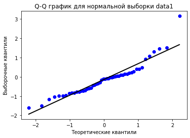

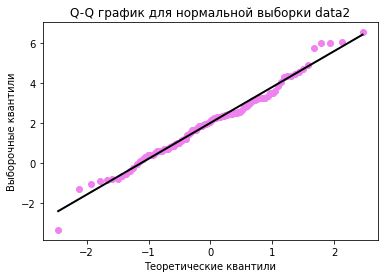

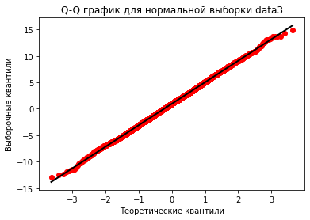

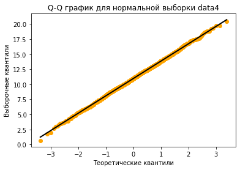

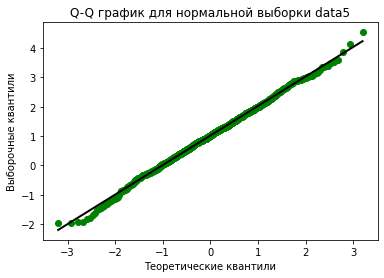

```python
qqgraph(data1, data_name="data1", point_color='blue')
qqgraph(data2, data_name="data2", point_color='violet')
qqgraph(data3, data_name="data3", point_color='red')
qqgraph(data4, data_name="data4", point_color='orange')
qqgraph(data5, data_name="data5", point_color='green')
```

#### Анализ с помощью графиков метода огибающих

```python
def my_envelope(data, data_name="", color="blue", confidence=0.99):
    data_sorted = np.sort(data)
    n = len(data)
    (osm, osr), (slope, intercept, r) = stats.probplot(data, dist="norm")
    plt.scatter(osm, osr, color=color, edgecolor="black", label="Data")
    plt.plot(osm, slope * osm + intercept, color=color, lw=2, label="Q-Q Line")
    z = stats.norm.ppf(1 - (1 - confidence) / 2)
    se = (slope / np.sqrt(n)) * np.sqrt(1 + osm ** 2)
    upper_bound = slope * osm + intercept + z * se
    lower_bound = slope * osm + intercept - z * se
    plt.fill_between(osm, lower_bound, upper_bound, color=color, alpha=0.2, label=f"{int(confidence * 100)}% Envelope")
    plt.xlabel("Квантили нормального распределения")
    plt.ylabel("Наблюдаемые квантили")
    plt.title(f"Метод огибающих для нормальной выборки {data_name}")
    plt.legend(loc="best")
    plt.show()
```

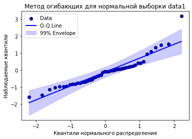

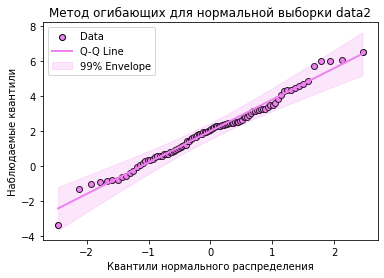

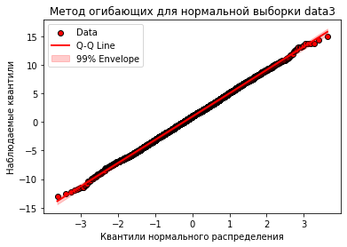

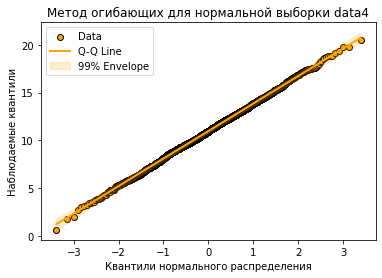

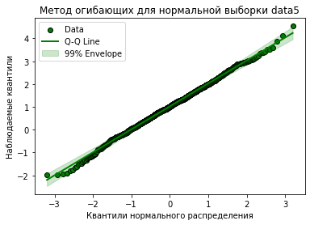

```python
my_envelope(data1, data_name="data1", color="blue", confidence=0.99)
my_envelope(data2, data_name="data2", color="violet", confidence=0.99)
my_envelope(data3, data_name="data3", color="red", confidence=0.99)
my_envelope(data4, data_name="data4", color="orange", confidence=0.99)
my_envelope(data5, data_name="data5", color="green", confidence=0.99)
```

#### Стандартные процедуры проверки гипотез о нормальности

1. критерий Колмогорова-Смирнова

```python
from scipy.stats import kstest

print("data1: ", kstest(data1, 'norm', args=(0, 1)))
print("data2: ", kstest(data2, 'norm', args=(2, 2)))
print("data3: ", kstest(data3, 'norm', args=(1, 4)))
print("data4: ", kstest(data4, 'norm', args=(11, 3)))
print("data5: ", kstest(data5, 'norm', args=(1, 1)))
```

```
data1:  KstestResult(statistic=0.1961597088452739, pvalue=0.03677650951349298, statistic_location=0.9008264869541871, statistic_sign=-1)
data2:  KstestResult(statistic=0.05756162456893493, pvalue=0.8756817049056109, statistic_location=0.7283078432422381, statistic_sign=1)
data3:  KstestResult(statistic=0.014944653190702262, pvalue=0.2119408333069457, statistic_location=1.9870640959198824, statistic_sign=1)
data4:  KstestResult(statistic=0.019500955099870487, pvalue=0.42697763325086735, statistic_location=11.88104207361908, statistic_sign=1)
data5:  KstestResult(statistic=0.037340004125404724, pvalue=0.119939928312772, statistic_location=1.4611653095704993, statistic_sign=1)
```

`p-value > 0.05` верно для всех выборок, кроме `data1` (мало данных).

```python
print("data1-data3: ", kstest(data1, data3))
print("data4-data5: ", kstest(data4, data5))
```

```
data1-data3:  KstestResult(statistic=0.4238, pvalue=1.4182253473298518e-08, statistic_location=1.5227024658475823, statistic_sign=1)
data4-data5:  KstestResult(statistic=0.9915, pvalue=0.0, statistic_location=3.529022743216132, statistic_sign=-1)
```

В обоих случаях `p-value < 0.05`, поэтому выборки принадлежат разным распределениям.

2. критерий Шапиро-Уилка

```python
from scipy.stats import shapiro

print("data1: ", shapiro(data1))
print("data2: ", shapiro(data2))
print("data3: ", shapiro(data3))
print("data4: ", shapiro(data4))
print("data5: ", shapiro(data5))
```

```
data1:  ShapiroResult(statistic=0.9833310504922841, pvalue=0.6981744321420791)
data2:  ShapiroResult(statistic=0.9769408845266334, pvalue=0.0765932336480898)
data3:  ShapiroResult(statistic=0.9996966049834742, pvalue=0.6964218360802187)
data4:  ShapiroResult(statistic=0.9990083571345875, pvalue=0.33996143415788815)
data5:  ShapiroResult(statistic=0.9984497356940084, pvalue=0.5222332243819501)
```

`p-value > 0.05` для всех выборок, поэтому все данные действительно принадлежат нормальному распределению.

3. критерий Андерсона-Дарлинга

```python
from scipy.stats import anderson

print("data1: ", anderson(data1))
print("data2: ", anderson(data2))
print("data3: ", anderson(data3))
print("data4: ", anderson(data4))
print("data5: ", anderson(data5))
```

```
data1:  AndersonResult(statistic=1.0866208133550188, critical_values=array([0.538, 0.613, 0.736, 0.858, 1.021]), significance_level=array([15. , 10. ,  5. ,  2.5,  1. ]), fit_result=  params: FitParams(loc=-0.13251355947922405, scale=0.8422989408191652)
 success: True
 message: '`anderson` successfully fit the distribution to the data.')
data2:  AndersonResult(statistic=0.41840875893601037, critical_values=array([0.555, 0.632, 0.759, 0.885, 1.053]), significance_level=array([15. , 10. ,  5. ,  2.5,  1. ]), fit_result=  params: FitParams(loc=2.017317121539163, scale=1.7835795568140702)
 success: True
 message: '`anderson` successfully fit the distribution to the data.')
data3:  AndersonResult(statistic=0.32053706227088696, critical_values=array([0.576, 0.655, 0.786, 0.917, 1.091]), significance_level=array([15. , 10. ,  5. ,  2.5,  1. ]), fit_result=  params: FitParams(loc=0.9426271756464132, scale=4.068015386175755)
 success: True
 message: '`anderson` successfully fit the distribution to the data.')
data4:  AndersonResult(statistic=0.3036561758672178, critical_values=array([0.575, 0.655, 0.785, 0.916, 1.09 ]), significance_level=array([15. , 10. ,  5. ,  2.5,  1. ]), fit_result=  params: FitParams(loc=10.970757224855257, scale=2.8715640515837446)
 success: True
 message: '`anderson` successfully fit the distribution to the data.')
data5:  AndersonResult(statistic=0.2566002648554786, critical_values=array([0.574, 0.653, 0.784, 0.914, 1.088]), significance_level=array([15. , 10. ,  5. ,  2.5,  1. ]), fit_result=  params: FitParams(loc=1.0183165002161498, scale=1.0041741253616474)
 success: True
 message: '`anderson` successfully fit the distribution to the data.')
```

4. критерий Крамера фон Мизеса

```python
# Python
from scipy.stats import cramervonmises

print("data1: ", cramervonmises(data1, 'norm', args=(0, 1)))
print("data2: ", cramervonmises(data2, 'norm', args=(2, 2)))
print("data3: ", cramervonmises(data3, 'norm', args=(1, 4)))
print("data4: ", cramervonmises(data4, 'norm', args=(11, 3)))
print("data5: ", cramervonmises(data5, 'norm', args=(1, 1)))
```

```
data1:  CramerVonMisesResult(statistic=0.035265855376004164, pvalue=0.9573149647061584)
data2:  CramerVonMisesResult(statistic=0.29108005875011583, pvalue=0.14320148242596809)
data3:  CramerVonMisesResult(statistic=0.07334202420065233, pvalue=0.7312429946063369)
data4:  CramerVonMisesResult(statistic=0.09562257348312944, pvalue=0.6068108519778788)
data5:  CramerVonMisesResult(statistic=0.042870026247149355, pvalue=0.9179161899904564)
```

`p-value > 0.05` для всех выборок, поэтому гипотеза о принадлежности конкретным для каждой выборки распределениям не отвергается.

5. критерий Колмогорова-Смирнова в модификации Лиллиефорса

Этот критерий на Python возвращает два параметра: значение статистики и p-value.

```python
# Python
from statsmodels.stats.diagnostic import lilliefors

print("data1: ", lilliefors(data1, 'norm'))
print("data2: ", lilliefors(data2, 'norm'))
print("data3: ", lilliefors(data3, 'norm'))
print("data4: ", lilliefors(data4, 'norm'))
print("data5: ", lilliefors(data5, 'norm'))
```

```
data1:  (0.08853731022257405, 0.4229838601698311)
data2:  (0.062190867774230385, 0.4508887029010543)
data3:  (0.005620969612045668, 0.9653828027812171)
data4:  (0.015959350035964714, 0.2622806756664616)
data5:  (0.02838957649474816, 0.07196272230791062)
```

`p-value > 0.05` для всех выборок, поэтому они распределены нормально.

6. критерий Шапиро-Франсия

```python
from sfrancia import shapiroFrancia


print("data1: ", shapiroFrancia(data1))
print("data2: ", shapiroFrancia(data2))
print("data3: ", shapiroFrancia(data3))
print("data4: ", shapiroFrancia(data4))
print("data5: ", shapiroFrancia(data5))
```

```
data1:  {'method': 'Shapiro-Francia normality test', 'statistics W': 0.9828005194642688, 'statistics z': -0.2072911584487617, 'p-value': 0.5821087606355897}
data2:  {'method': 'Shapiro-Francia normality test', 'statistics W': 0.9807777636812348, 'statistics z': 1.1051837380042415, 'p-value': 0.13453999092697672}
data3:  {'method': 'Shapiro-Francia normality test', 'statistics W': 0.9997158972088828, 'statistics z': -0.4722162283179338, 'p-value': 0.681613771270173}
data4:  {'method': 'Shapiro-Francia normality test', 'statistics W': 0.9995557256725921, 'statistics z': -1.3972755961386651, 'p-value': 0.9188346442632438}
data5:  {'method': 'Shapiro-Francia normality test', 'statistics W': 0.9990984681054618, 'statistics z': -1.1568368473339077, 'p-value': 0.8763304878320161}
```

`p-value > 0.05` для всех выборок, поэтому они распределены нормально.